# Analysis of Public Policy (30700953)

Dr. Yue Hu

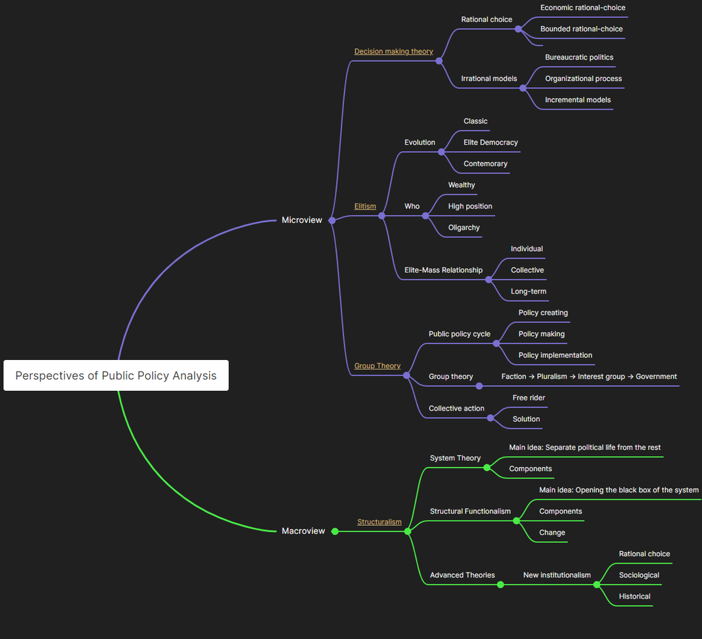

Welcome to the lecture sources for the *Analysis of Public Policy*. Learn how to analyze public polices with Dr. Hu.

[figure not shown]

- 第1周 (2022-02-21): 课程介绍 (Introduction)
- 第2周 (2022-02-28): 科学视角下的政策分析 (Approach: A Scientific View)
- 第3周 (2022-03-07): 视角：决策过程理论 (Perspective: Decision-Making Theory)
- 第4周 (2022-03-14): 视角：精英理论 (Perspective: Elitism)
- 第5周 (2022-03-21): 视角：团体理论 (Perspective: Group Theory)
- 第6周 (2022-03-28): 视角：政治系统理论 (Perspective: System Theory)
- 第7周 (2022-04-04): 哗啦啦，放假啦！ (Public Holiday)
- 第8周 (2022-04-11): 视角：结构功能主义 (Perspective: Functionalism)
- 第9周 (2022-04-18): 方法：实验逻辑 (Method: Experimental Logic)
- 第10周 (2022-04-25): 方法：调研与大样本分析 (Method: Survey and Large-N)
- 第11周 (2022-05-06): 方法：大数据分析 (Method: “Big Data”)
- 第12周 (2022-05-09): 方法：小样本分析 (Method: Small-N)
- 第13周 (2022-05-16): 方法：案例分析 (Method: Case Study)
- 第14周 (2022-05-23): 方法：解释性分析 (Method: Interpretive Analysis)
- 第15周 (2022-05-30): 期末项目报告 (Student Presentation)
- 第16周 (2022-06-06): 如何在一个周末完成一篇B+以上论文 (Professionalization)